# Bayesian chronological modeling in OxCal through R

Elisabetta Canteri

2025-09-19

# Introduction

This document aims at explaining the role of the functions used in the paper *“Automated chronological modelling of large quantities of 14C dates within a Bayesian framework”*. We will start with an overview of all the functions and then move to a few examples of how they were used in the paper. We will also briefly show how the data was cleaned and processed so that it is in the correct format for the functions.

All data and code used in the paper is provided separately in the Supplementary Materials.

## OxCal installation

To run the functions and reproduce the results in the paper, OxCal needs to be installed on a computer or an external server. To do so, please follow the installation instructions on the OxCal website at https://c14.arch.ox.ac.uk/oxcalhelp/readme.html#local

# Functions

The functions used in the paper are divided in three categories:

1. Grouping of 14C dates based on the material used for dating.
2. Functions to write the OxCal CQL input scripts.
3. Functions to extract the model output.

First of all, let’s load the R file with the functions.

```r
source("./Scripts/FunctionsOxCal.R")
```

We can see that now they are all loaded in our Global Environment.

## Grouping

The function used for grouping is called `classify`. This function assigns the 14C dates to a group (1,2,3) based on the material and taxon that was used for dating. Being assigned to the group “1” means that the 14C date belongs to a short-lived taxon/material, group “2” is for medium-lived and group “3” is for long-lived.

It takes 3 parameters: `material`, `material.species`, and `material.notes`. `material` can be anything like grain, seed, bone, charcoal, etc. `material.species` refers to the specific taxon, if available, related to that material. `material.notes` is added because in our data, sometimes the taxon or material was specified in the notes.

```r
print(classify)
```

```
## function (material, material.species, material.notes)
## {
##     p <- NA
##     if (material %in% material_groups$short) {
##         p <- 1
##         if (material %in% c("bone", "tooth", "bone / tooth") &&
##             material.species %in% species_groups$medium) {
##             p <- 2
##         }
##     }
##     else if (material %in% material_groups$medium) {
##         p <- 2
##     }
##     else if (material %in% material_groups$long) {
##         p <- 3
##         if (material.species %in% species_groups$medium) {
##             p <- 2
##         }
##         if (is.na(material.species)) {
##             if (sum(unlist(lapply(species_groups$medium, function(x) {
##                 grep(x, material.notes)
##             }))) > 0) {
##                 p <- 2
##             }
##             if (sum(unlist(lapply(species_groups$long, function(x) {
##                 grep(x, material.notes)
##             }))) > 0) {
##                 p <- 3
##             }
##         }
##     }
##     return(p)
## }
```

In our chronological models, we assign an outlier probability of 1 for each group that is not “1”, i.e. for each radiocarbon date that does not belong to a short-lived taxon/material.

## OxCal input

To run chronological models in OxCal, the input script needs to have a specific structure. Given that our goal was to date phases, the model requires information about sequences, boundaries, radiocarbon dates, calibration curve, phases, and outlier models.

We have therefore created a set of functions that creates the text for each of these, in the correct format. For the boundaries, we added an option to say whether the phases are sequential or not, so whether we have a start and end boundary for each phase, or whether we need to have a transition between phases.

Here is an example when having sequential phases:

```r
Boundary(c("Phase1", "Phase2"), sequential = TRUE)
```

```
## [[1]]
## [1] "Boundary(\"B_Start Phase1\");" "Boundary(\"B_End Phase1\");"
##
## [[2]]
## [1] "Boundary(\"B_Start Phase2\");" "Boundary(\"B_End Phase2\");"
```

The output is a list with 2 elements, each element containing the input text related to the boundary for each phase.

Here is the same example with overlapping phases:

```r
Boundary(c("Phase1", "Phase2"), sequential = FALSE)
```

```
## [[1]]
## [1] "Boundary(\"B_Start Phase1\");"
##
## [[2]]
## [1] "Boundary(\"B_Transition Phase1/Phase2\");"
## [2] "Boundary(\"B_End Phase2\");"
```

As we can see, Phase 1 only has a start, while Phase 2 has a transition and then an end.

Here is a list of all the functions:

- `Curve`: takes a parameter `calcurve`, which is a character string. Possible curve choices are: “IntCal20”, “SHCal20”, “Marine20”. Calibration curves must be downloaded from the OxCal website and the local path where they are stored on the computer must be indicated in the `calcurvepath` parameter.
- `Sequence`: takes a parameter `name`, which is just a character string of own choice. Outputs a list containing the sequence information for the OxCal model.
- `Boundary`: as explained before, it takes a character string (names of the boundaries) and whether they are sequential or not.
- `RDates`: it takes 3 parameters. `d` are the radiocarbon dates. This is a data frame consisting of three columns (“LabID”, “C14.Age”, “C14.SD”), with labcode, radiocarbon age and radiocarbon age error. `outlier` can be set either TRUE or FALSE, depending on whether one wants to model the radiocarbon date according to a specific outlier model, and, in that case, the outlier probability is set using the `outlier.prob` parameter. If using a specific outlier model, the function requires the data frame of radiocarbon dates to include three additional columns: “OutlierProb”, “Material” and “TaxonCode”. “OutlierProb” gives a number for the outlier probability of each date, while “Material” and “TaxonCode” contain information about the material/taxon used for dating, which will match a tailor-made outlier model. “Material” cannot be blank (NA).
- `Phases`: takes a parameter `p` which is a character string. Used to name the phase.
- `Date`: this is equivalent to the `Date()` function in OxCal. It takes a parameter `p` which is a character string defining the name of the phase to be dated.
- `OutlierModels`: this function will print the code for a specific outlier model based on the “group” of the radiocarbon date (see “Grouping” section above), the material and the taxon of the sample used for dating. The function takes a parameter `d`, which is the data frame of radiocarbon dates. This data frame must include a column “Group” that indicates to which group the radiocarbon dates belong to. The “Group” is assigned using the `classify` function explained above. Other parameters of this function are `exp.species` and `exp.material`. These are two data frames (provided in Supplementary Material) with the values needed to create the custom outlier models based on specific materials and taxa.

The outputs of all functions are in “list” format. These outputs are then combined together with the function `OxCal_input`.

- `OxCal_input`: takes 7 parameters. `curve`, `out.model`, `bound`, `phases`, `rdates`, and `date_p` are the variables created with the functions listed above for the calibration curve, the outlier model, the boundaries, phases, radiocarbon dates and phase date function. There is an extra parameter called `phase_type`, which can either be NULL (not specified) or “overlapping”. If set to “overlapping”, the OxCal input script will structure the code so that it takes into account transitional boundaries among phases.

## OxCal output

These functions are used to extract the values of the model from the .js output file. The coding of these functions has been inspired by a blog post written by Richard Telford (https://quantpalaeo.wordpress.com/2016/11/19/oxcal-and-r/), which we would like to thank.

All functions include a parameter `js` which needs to be specified with the jason (.js) output file created when an OxCal model finishes running.

- `get.values`: extracts either likelihood or posterior values (when `posterior = T`) of any `target` (e.g. mean, sigma, median calibrated dates) from the output file.
- `get.model.agreement`: extracts model agreement indices. In this case, the `target` parameter can either be “model” or “overall”.
- `get.lab.codes`: extracts the IDs of the radiocarbon dates in the model.
- `get.outlier`: extracts the prior and posterior probabilities of the outlier model and outlier sample (if specified). For more information visit https://c14.arch.ox.ac.uk/oxcalhelp/hlp_analysis_oper.html#outlier (Bronk Ramsey 2009)
- `get.probs`: extracts either likelihood or posterior (when `posterior = T`) probabilities of the radiocarbon samples listed in the OxCal model. The output is in BC/AD unless `calBP = TRUE`, where calibrated dates are converted to calBP.
- `get.results`: extracts the complete model output. This function will read the OxCal output from a directory specified with `filepath`, and will generate a set of tables:
  - “**dates**” table with uncalibrated and calibrated dates (mean, sigma, median, 68.3 and 95.4 posterior ranges) for start and end boundaries, radiocarbon samples and phases. The dates will be in BC/AD unless `calBP = TRUE`.
  - “**phase**” table with the calibrated dates for phases in the OxCal model (mean, sigma, median, 68.3 and 95.4 posterior ranges). The dates will be in BC/AD unless `calBP = TRUE`.
  - “**model**” table with likelihood and posterior probabilities for the parameters specified in the `Outlier_Model`, if specified.
  - “**outlier**” table with prior and posterior probabilities of a measure to be an outlier. Measures are usually the `Outlier_Model` and the radiocarbon samples.
  - “**agreement**” table with the agreement indices for individual samples (`A`), the model (`A_model`) and the overall individual agreement index (`A_overall`).

    This function takes 8 parameters:
    - `filepath`: path to the directory with the model outputs.
    - `outdir`: path to the directory where to store results tables.
    - `site_id`: the name of the site of the model. Can be NULL, but this value is used to recognize the name of the files.
    - `phase_id`: the names of the phases as provided in the data. This parameter **cannot** be NULL.
    - `phase_dating`: logical (TRUE or FALSE). This parameter sets whether the modelled posteriors are to be extracted.
    - `outlier`: logical (TRUE or FALSE). This parameter sets whether the modelled posteriors for the outlier model are to be returned and the “outlier” table to be created.
    - `output.list`: logical (TRUE or FALSE). This parameter sets whether to not only write the results tables to file, but also to store them in a list.
    - `calBP`: logical (TRUE or FALSE). This parameter sets whether to return the calibrated dates in BC/AD or in calBP.

# Examples

Here we are going to show two examples: one with an automated script for single-phase sites, and one showing how we coded a multi-phase site. We will start by giving an overview of the data and how we processed it and then move to the examples.

### Data

We start by loading the libraries. These are required packages that need to be installed to be able to run the code below.

```r
library(data.table)
library(stringr)
library(gtools)
library(pals)
library(ggplot2)
library(pbapply)
library(parallel)
library(doSNOW)
library(rjson)
```

Now we can import the data:

```r
DT <- readRDS("./Data/Crops.RData")
str(DT)
```

```
## Classes 'data.table' and 'data.frame':   2128 obs. of  11 variables:
##  $ Group    : chr  "Hulled barley" "Glume wheats" "Legumes" "Linum usitatissimum" ...
##  $ PhaseID  : chr  "AB" "AB" "OZ" "OZ" ...
##  $ SiteID   : chr  "S01011" "S01011" "S01051" "S01051" ...
##  $ SeedCount: int  0 0 6 1 6377 3 1674 2 4 161 ...
##  $ Latitude : num  51.7 51.7 50.7 50.7 50.7 ...
##  $ Longitude: num  -1.26 -1.26 5.28 5.28 5.28 ...
##  $ Period   : chr  "EN" "EN" "EN" "EN" ...
##  $ P1       : num  0.1372 0.5065 0.0585 0.01 1 ...
##  $ P50      : num  0.86 0.973 0.984 0.5 1 ...
##  $ P99      : num  0.998 1 1 0.99 1 ...
##  $ P        :List of 2128
##   ..$ : num  0.137 0.22 0.286 0.34 0.384 ...
##   ..$ : num  0.506 0.62 0.687 0.732 0.766 ...
##   ..$ : num  0.0585 0.1142 0.167 0.2172 0.2649 ...
##   ..$ : num  0.01 0.02 0.03 0.04 0.05 ...
##   ..$ : num  1 1 1 1 1 1 1 1 1 1 ...
##   ..$ : num  0.0297 0.0588 0.0873 0.1153 0.1426 ...
##   ..$ : num  1 1 1 1 1 ...
##   ..$ : num  0.0199 0.0396 0.0591 0.0784 0.0975 ...
##   ..$ : num  0.0394 0.0776 0.1147 0.1507 0.1855 ...
##   ..$ : num  0.802 0.961 0.993 0.999 1 ...
##   ..$ : num  0.0199 0.0396 0.0591 0.0784 0.0975 ...
##   ..$ : num  0.436 0.684 0.824 0.902 0.946 ...
##   ..$ : num  0.01 0.02 0.03 0.04 0.05 ...
##   ..$ : num  0.945 0.997 1 1 1 ...
##   ..$ : num  0.615 0.853 0.945 0.979 0.992 ...
##   ..$ : num  0.01 0.02 0.03 0.04 0.05 ...
##   ..$ : num  0.0394 0.0776 0.1147 0.1507 0.1855 ...
##   ..$ : num  0.0297 0.0588 0.0873 0.1153 0.1426 ...
##   ..$ : num  1 1 1 1 1 ...
##   ..$ : num  0.929 0.995 1 1 1 ...
##   ..$ : num  1 1 1 1 1 ...
##   ..$ : num  0.954 0.998 1 1 1 ...
##   ..$ : num  0.127 0.191 0.243 0.288 0.328 ...
##   ..$ : num  0.349 0.416 0.458 0.493 0.522 ...
##   ..$ : num  0.162 0.248 0.306 0.35 0.385 ...
##   ..$ : num  0.01 0.02 0.03 0.04 0.05 ...
##   ..$ : num  0.494 0.593 0.655 0.7 0.734 ...
##   ..$ : num  0.9 0.99 0.999 1 1 ...
```

[output cut: 60 more lines]

```
##   ..$ : num  0.182 0.332 0.456 0.558 0.642 ...
##   ..$ : num  0.01 0.02 0.03 0.04 0.05 ...
##   ..$ : num  1 1 1 1 1 1 1 1 1 1 ...
##   ..$ : num  0.0297 0.0588 0.0873 0.1153 0.1426 ...
##   ..$ : num  0.469 0.72 0.853 0.924 0.961 ...
##   ..$ : num  0.01 0.02 0.03 0.04 0.05 ...
##   ..$ : num  0.105 0.199 0.285 0.362 0.431 ...
##   ..$ : num  0.01 0.02 0.03 0.04 0.05 ...
##   ..$ : num  0.122 0.231 0.327 0.412 0.487 ...
##   ..$ : num  0.01 0.02 0.03 0.04 0.05 ...
##   ..$ : num  0.993 1 1 1 1 ...
##   .. [list output truncated]
##  - attr(*, ".internal.selfref")=<externalptr>
##  - attr(*, "index")= int(0)
##   ..- attr(*, "__Group")= int [1:2128] 652 916 999 1249 1273 1282 1329 1401 1455 1463 ...
```

This is the data we have on archaeobotanical samples. The aim is to date the phases in which we have these samples. We will use radiocarbon dates associated to the phases to create chronological models in OxCal which will give us the temporal range of these phases.

Here are the radiocarbon samples for our phases:

```r
dates <- fread("./Data/Dates_raw.csv", na.strings = "")
str(dates)
```

```
## Classes 'data.table' and 'data.frame':   2178 obs. of  29 variables:
##  $ SiteID         : chr  "S01011" "S01011" "S01011" "S01011" ...
##  $ C14ID          : int  8612 25002 25003 25004 25005 8285 8318 8443 8444 8445 ...
##  $ PhaseID        : chr  "AB" "AB" "AB" "AB" ...
##  $ ItemID         : chr  NA NA NA NA ...
##  $ Period         : chr  "EN" "EN" "EN" "EN" ...
##  $ Method         : chr  "LSC" "LSC" "LSC" "LSC" ...
##  $ C14.Age        : int  4730 4910 5060 4710 4970 6370 6300 6510 6360 6330 ...
##  $ C14.SD         : int  135 110 130 135 130 95 100 80 360 100 ...
##  $ δ13C           : num  NA NA NA NA NA NA NA NA NA NA ...
##  $ δ13C.SD        : num  NA NA NA NA NA NA NA NA NA NA ...
##  $ C/N_collagen   : num  NA NA NA NA NA NA NA NA NA NA ...
##  $ LabID          : chr  "BM-348" "BM-350" "BM-351" "BM-352" ...
##  $ Prefix         : chr  "BM" "BM" "BM" "BM" ...
##  $ AltLabID       : chr  NA NA NA NA ...
```

[output cut: 16 more lines]

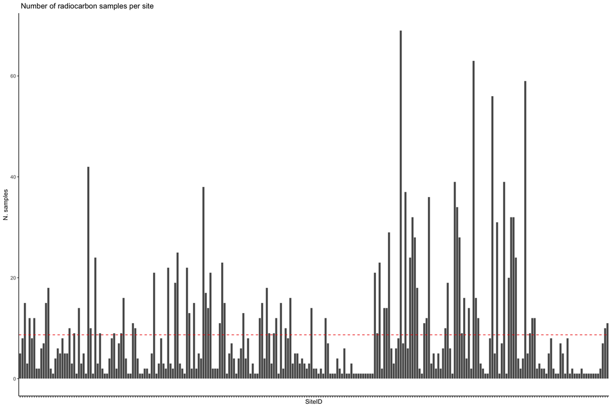

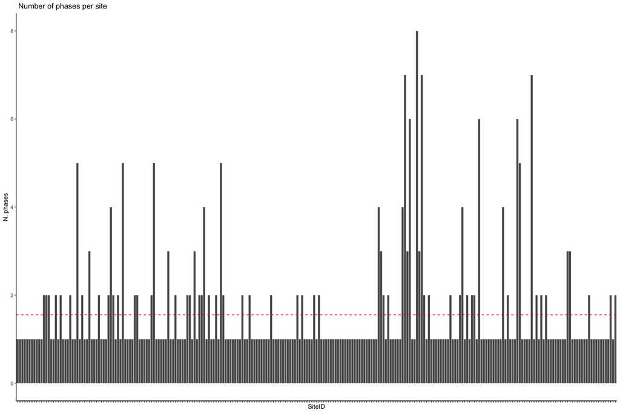

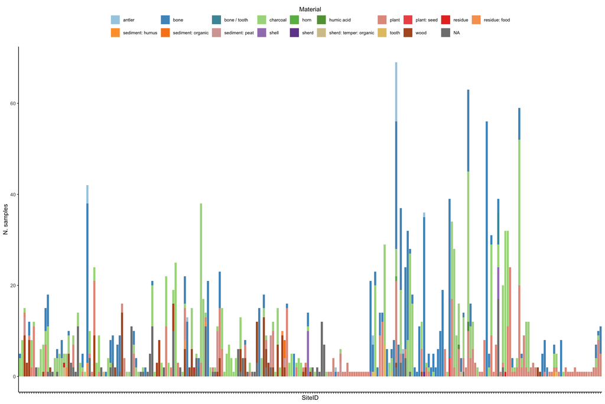

### Grouping

Here we group by age, by dividing species between short-lived, medium-lived, and long-lived. The short-lived will give more precise calibration compared to the others, so they will have high priority when selecting 14C dates. For all other materials, we will have to see case by case, but some of them will not be used because unreliable. We will put them in a separate category, so we can still use them as last resort.

- Short-lived are plants and animals up to 10 years of lifespan
- Medium-lived are up to 100 years
- Long-lived are >100 years

```r
## Separate rows where "Material" is from completely unreliable sources
material.remove <- c(NA, "residue: food", "carbonised residue", "sediment: organic", "organic substance", "shell", "residue", "sediment: humus", "shell",
            "soil", "charred food residue", "potsherd", "humic acid")
taxa.remove <- c("piscind", "phocind", "MOSBRSP")
unreliable <- dates[Material %in% material.remove | TaxonCode %in% taxa.remove]
unreliable <- rbind(unreliable, dates[grep("contamination", Flag)])

# Remove also duplicated dates and date contamination
dates <- dates[!(Material %in% material.remove | TaxonCode %in% taxa.remove)]
dates <- dates[grep("contamination", Flag, invert = T)]
```

Now we create the groups for materials and taxa. And we assign the groups to the radiocarbon dates using the `classify` function.

```r
## Group
material_groups <- list(short = c("organic temper", "bone (charred)", "bone", "charred plant macrofossils", "plant macrofossils",
                                  "animal bone", "antler", "grain", "seed", "tooth", "grain (charred)", "bone / tooth",
                                  "horn", "fruit (charred)", "acorn", "fruit", "Nutshell", "grain", "resin"),
                        medium = c("human bone"),
                        long = c("sediment: peat", "charcoal", "wood"))

species_groups <- list(short = c("animind", "bosspec", "bostaur", "CERINDO", "canifam", "caprhir", "cervela", "equuspe",
                                 "FILIVUL", "HORDSPE", "HORSHUN", "HORSNAK", "LINUSPE", "mamindl", "mammind", "ovicapwd",
                                 "ovisari", "oviscap", "ovismus", "ovisspe", "PANIMIL", "PHRASPE", "PISUSPE", "POACIND",
                                 "ruminde", "susscrd", "susscrf", "susspec", "TRIAEST", "TRIDISP", "TRIMODI", "TRITDIC",
                                 "TRITHOR", "TRITMON", "TRITSPE", "TRITSPL", "FALLCON", "AVENSPE", "unguind", "VISCALB",
                                 "VICIERV", "LENSCUL", "caprcap", "boscerv", "equuhyd", "cervind", "bosprim", "CARESPE",
                                 "PHRAAUS", "RANUFIC", "HORSHUL", "SETAITA", "CHENHYB", "VICISPE", "PISUSAT", "LINUUSI",
                                 "LATHSPE"),
                       medium = c("CORYAVE", "ALNUSPE", "BETUSPE", "CORNSAN", "CORYSPE", "homosap", "MALOIDE",
                                  "POPUSPE", "ROSAIND", "ROSASPE", "SALISPE", "PRUNSPI", "MALUSYL", "PYRUSPE"),
                       long = c("ABIESPE", "ACERSPE", "ARBDECI", "FAGUSPE", "FRAXSPE", "JUNISPE", "PINUSPE",
                                "QUERSPE", "TILISPE", "FRAXELC", "ULMUSPE", "QUERPUB")
)

## Assign groups
dates[, Group := sapply(1:nrow(dates), function(n){
  material <- dates$Material[n]
  material.species <- dates$TaxonCode[n]
  material.notes <- dates$MaterialNotes[n]
  return(classify(material, material.species, material.notes))
})]
```

Finally, we assign the outlier probability to the radiocarbon dates based on the groups they belong to.

```r
## Asign outlier probability based on group
# Here we give a probability of 1 when the material is not short-lived
dates[, OutlierProb := sapply(Group, function(g) ifelse(g > 1, 1, 0))]
```

```r
str(dates)
```

```
## Classes 'data.table' and 'data.frame':   1781 obs. of  26 variables:
##  $ SiteID       : chr  "S01011" "S01011" "S01011" "S01011" ...
##  $ C14ID        : int  8612 25002 25003 25004 25005 8285 8318 8443 8444 8445 ...
##  $ PhaseID      : chr  "AB" "AB" "AB" "AB" ...
##  $ ItemID       : chr  NA NA NA NA ...
##  $ Period       : chr  "EN" "EN" "EN" "EN" ...
##  $ C14.Age      : int  4730 4910 5060 4710 4970 6370 6300 6510 6360 6330 ...
##  $ C14.SD       : int  135 110 130 135 130 95 100 80 360 100 ...
##  $ δ13C         : num  NA NA NA NA NA NA NA NA NA NA ...
##  $ δ13C.SD      : num  NA NA NA NA NA NA NA NA NA NA ...
##  $ C/N_collagen : logi  NA NA NA NA NA NA ...
##  $ LabID        : chr  "BM-348" "BM-350" "BM-351" "BM-352" ...
##  $ Prefix       : chr  "BM" "BM" "BM" "BM" ...
##  $ AltLabID     : chr  NA NA NA NA ...
##  $ AltPrefix    : chr  NA NA NA NA ...
##  $ TaxonCode    : chr  NA NA NA "bosspec" ...
##  $ Material     : chr  "charcoal" "charcoal" "charcoal" "animal bone" ...
##  $ MaterialNotes: chr  NA NA NA NA ...
##  $ Flag         : chr  NA NA NA NA ...
##  $ ContextType  : chr  NA NA NA NA ...
##  $ Context      : chr  NA NA NA NA ...
##  $ CitationID   : chr  NA NA NA NA ...
##  $ Longitude    : num  -1.26 -1.26 -1.26 -1.26 -1.26 ...
##  $ Latitude     : num  51.7 51.7 51.7 51.7 51.7 ...
##  $ Country      : chr  "Great Britain" "Great Britain" "Great Britain" "Great Britain" ...
##  $ Group        : int  3 3 3 1 3 3 3 3 3 3 ...
##  $ OutlierProb  : int  1 1 1 0 1 1 1 1 1 1 ...
##  - attr(*, ".internal.selfref")=<externalptr>
```

As we can see, our data now contains a column called “Group” and a column called “OutlierProb”. The latter will be used for the OxCal models.

## 1. Automated chronological model for single-phase sites

Now we are going to present how to automatically run an OxCal model for 10 single-phase sites.

```r
# Get IDs of single-phase sites
sites_idx <- dates[, length(unique(PhaseID)), by = "SiteID"][V1 == 1, SiteID]

# Get IDs of single-phase sites that have 3 or more radiocarbon dates
sites_idx <- dates[SiteID %in% sites_idx][, .N, by = "SiteID"][N >= 3, SiteID]

# Create new table with 10 random single-phase sites that have 3 or more radiocarbon dates
dt <- dates[SiteID %in% sample(sites_idx, 10)]
str(dt)
```

```
## Classes 'data.table' and 'data.frame':   108 obs. of  26 variables:
##  $ SiteID       : chr  "S01011" "S01011" "S01011" "S01011" ...
##  $ C14ID        : int  8612 25002 25003 25004 25005 11468 11469 11471 11472 11473 ...
##  $ PhaseID      : chr  "AB" "AB" "AB" "AB" ...
##  $ ItemID       : chr  NA NA NA NA ...
##  $ Period       : chr  "EN" "EN" "EN" "EN" ...
##  $ C14.Age      : int  4730 4910 5060 4710 4970 5030 4960 4950 6010 4900 ...
##  $ C14.SD       : int  135 110 130 135 130 140 155 250 110 110 ...
##  $ δ13C         : num  NA NA NA NA NA -26.4 -28.5 -26 -28.8 -25.9 ...
##  $ δ13C.SD      : num  NA NA NA NA NA NA NA NA NA NA ...
##  $ C/N_collagen : logi  NA NA NA NA NA NA ...
##  $ LabID        : chr  "BM-348" "BM-350" "BM-351" "BM-352" ...
##  $ Prefix       : chr  "BM" "BM" "BM" "BM" ...
##  $ AltLabID     : chr  NA NA NA NA ...
##  $ AltPrefix    : chr  NA NA NA NA ...
##  $ TaxonCode    : chr  NA NA NA "bosspec" ...
##  $ Material     : chr  "charcoal" "charcoal" "charcoal" "animal bone" ...
##  $ MaterialNotes: chr  NA NA NA NA ...
##  $ Flag         : chr  NA NA NA NA ...
##  $ ContextType  : chr  NA NA NA NA ...
##  $ Context      : chr  NA NA NA NA ...
##  $ CitationID   : chr  NA NA NA NA ...
##  $ Longitude    : num  -1.26 -1.26 -1.26 -1.26 -1.26 ...
##  $ Latitude     : num  51.7 51.7 51.7 51.7 51.7 ...
##  $ Country      : chr  "Great Britain" "Great Britain" "Great Britain" "Great Britain" ...
##  $ Group        : int  3 3 3 1 3 3 3 3 3 3 ...
##  $ OutlierProb  : int  1 1 1 0 1 1 1 1 1 1 ...
##  - attr(*, ".internal.selfref")=<externalptr>
```

Now we can use the information in this table to generate OxCal models. First of all, we have to specify the different directories for the models to run. These directories are: `oxcalpath` that tells where OxCal has been downloaded on the computer; `calcurvepath` that tells where the calibration curve to be used is stored on the computer; `filedir` that tells where the model outputs will be stored; and `oudir` where the results will be saved. We also import the tables with the information needed to define the outlier models using the `OutlierModels` function, and all the other functions to run OxCal explained above.

```r
## Assign directories
oxcalpath <- "/Users/msb290/Library/CloudStorage/OneDrive-UniversityofCopenhagen/PhaseDating/OxCal/bin/OxCalMac"
calcurvepath <- "/Users/msb290/Library/CloudStorage/OneDrive-UniversityofCopenhagen/PhaseDating/OxCal/bin/intcal20.14c"
filedir <- "/Users/msb290/Library/CloudStorage/OneDrive-UniversityofCopenhagen/PhaseDating/Vignette/Models/SinglePhase/"
outdir <- "/Users/msb290/Library/CloudStorage/OneDrive-UniversityofCopenhagen/PhaseDating/Vignette/Tables/SinglePhase/"

# Import data for outlier models
exp.material <- fread("Data/EXP_Material.csv")
exp.species <- fread("Data/EXP_Species.csv")

# OxCal functions
source("Scripts/FunctionsOxCal.R")
```

For our 10 single-phase sites, we are going to work in parallel so that we analyse 5 sites at the same time. Note that if using High Performance Computing (HPC), it would be possible to run tens to hundreds sites at the same time, based on the number of cores and memory capacity. Here is how to work in parallel:

```r
# Split data into a list, where each element of the list is a site
m <- dt[order(PhaseID, -C14.Age, SiteID)]
m <- split(dt, dt$SiteID)
length(m) # 10 tables
```

```
## [1] 10
```

```r
# Parallel setup
cls <- makeCluster(5) # work on 5 cores
clusterExport(cls, list("m", "exp.species", "exp.material", "Curve", "OutlierModels", "Boundary", "Phases", "RDates", "Date", "OxCal_input", "oxcalpath", "calcurvepath", "filedir", "outdir"))

# Run OxCal models
pbapply::pblapply(m, function(d){
  require(data.table)
  require(pbapply)

  # Reorder by decreasing age
  setorder(d, -C14.Age, by = PhaseID)

  # Curve
  calcurve <- Curve(calcurve = "IntCal20", calcurvepath)

  # Outlier Models
  models <- OutlierModels(d, exp.species, exp.material)

  # Boundary
  bound <- Boundary(unique(d$PhaseID), sequential = F)

  # Phases
  phases <- lapply(unique(d$PhaseID), function(n){Phases(unique(n))})

  # RDates
  rdates <- lapply(unique(d$PhaseID), function(n){
    db <- d[PhaseID == n]
    return(RDates(db, outlier = TRUE, outlier.prob = db$OutlierProb))
  })

  # Date phase
  date_p <- lapply(unique(d$PhaseID), function(n){Date(unique(n))})

  # Input
  command <- OxCal_input(calcurve, models, bound, phases, rdates, date_p)

  # Write to file
  filename <- sprintf(paste0(filedir, "/%s.input"), unique(d$SiteID))
  writeLines(command, con = filename)

  # Run OxCal
  # print(unique(d$SiteID))
  set.seed(1234)
  system(paste(oxcalpath, filename), ignore.stdout = T, ignore.stderr = T)
}, cl = cls)
stopCluster(cls); registerDoSEQ(); gc()
```

As we can see, the folder **“Models”** now contains, for each site, a **.input** file, a **.js** file, a **.log** file, and a **.txt** file.

The **.input** file contains the OxCal code for running the model, the one we generated using the `OxCal_input` function. The **.js** file contains the full model run, with results we are going to extract next. The **.log** contains the log of the model run and the **.txt** file contains part of the results of the model.

To extract the results, we are now using functions that will work on the **.js** and **.txt** files.

```r
# Extract results
pbapply::pblapply(m, function(x){
  get.results(filepath = filedir, outpath = outdir, site_id = unique(x$SiteID),
              phase_id = unique(x$PhaseID), calBP = T,
              output.list = F, phase_dating = T, outlier = T)
})
```

After running the `get.results` functions, new files have appeared in the **“Tables”** folder. These files include posterior information about the model agreement, the outlier probabilities, the outlier models, the calibrated radiocarbon dates, and the phase dating.

Given that our goal was to model the date of phases, we can extract this information separately and build a table only with phase dates.

```r
# Import phases result tables
phases_calib <- lapply(list.files("./Tables/SinglePhase/", pattern = "_phase.txt", full.names = T), read.delim)

# Check length of list
length(phases_calib)
```

```
## [1] 10
```

```r
# Create table
p.dt <- setDT(do.call(rbind, phases_calib))
p.dt$SiteID <- unique(dt$SiteID)
p.dt <- p.dt[, c(10, 1:9)]
p.dt
```

```
##     SiteID PhaseID From_68.3 To_68.3 From_95.4 To_95.4  mean sigma median
##     <char>  <char>     <int>   <int>     <int>   <int> <int> <int>  <int>
##  1: S01011      OZ      7324    7144      7449    7004  7231   106   7234
##  2: S01324     BBT      5152    4963      5279    4899  5076    96   5062
##  3: S02210     BTH      5719    5609      5835    5540  5671    67   5669
##  4: S04127    EBD1      6221    6035      6358    5891  6125   116   6126
##  5: S06914      FE      5095    4843      5325    4676  4985   154   4975
##  6: S08891 MNVLDV1      6966    6903      7011    6860  6936    37   6938
##  7: S08934      TY      5741    5550      5893    5374  5642   119   5648
##  8: S10076    SOP2      7892    6178      7991    6011  6994   592   6997
##  9: S10894  STARC1      7667    7506      7707    7456  7582    70   7583
## 10: S12505   HOKO1      2884    2793      2986    2726  2850    65   2852
##     YearType
##       <char>
##  1:    calBP
##  2:    calBP
##  3:    calBP
##  4:    calBP
##  5:    calBP
##  6:    calBP
##  7:    calBP
##  8:    calBP
##  9:    calBP
## 10:    calBP
```

## 2. Multi-phase site: S11258 Hestehaven, Denmark.

Here we are going to show how to use some of the functions to build and tailor the OxCal input script for a multi-phase site.

Hestehaven is a Late Neolithic-Early Bronze Age settlement located in Eastern Jutland. During 2011 excavation, four structures were identified and rich archaeobotanical assemblages from houses K1 and K4 provide important data about the agricultural practices in Denmark during the Late Neolithic-Early Bronze Age transition. A total of 9 AMS 14C ages measured on short-lived material from houses K1, K2 and K4 are available.

We have data for two phases: HESTE1 dated to the Late Neolithic and HESTE2 dated to the Early Bronze Age. Belonging to phase HESTE1 is house K4 which was a NE-SW oriented two-aisled house with a strong presence of collected food plants, in the form of acorns, apples, and hazelnuts. The house is typologically dated to the Late Neolithic. 2 samples of charred acorn (AAR-18535) and charred cereal (AAR-18536) were selected from posthole A282 and 14C dated. Belonging to phase HESTE2 are houses K1 and K2. House K1 was a E-W oriented two-aisled house with a sunken floor area in the eastern part. At the bottom of the sunken floor, directly above the sandy floor layer/subsoil, was an 8–10 cm thick charred layer (A212) containing large amounts of carbonised cereal grains. The grain layer was interpreted as the remains of a granary burned along with the house. The house is typologically dated to the Late Neolithic or Early Bronze Age. 4 samples of charred cereals were 14C dated from the grain layer (AAR-18540 – 43). House K2 was a NE-SW oriented two-aisled house, but further interpretations remain uncertain due to preservation issues. 3 samples of charred cereal (AAR-18537) and charred hazelnut shell (AAR-18538 – 39) were selected from context A386 and 14C dated.

```r
heste <- dates[SiteID == "S11258"]
heste
```

```
##    SiteID C14ID PhaseID ItemID Period C14.Age C14.SD  δ13C δ13C.SD C/N_collagen
##    <char> <int>  <char> <char> <char>   <int>  <int> <num>   <num>       <lgcl>
## 1: S11258 28094  HESTE1   <NA>     LN    3567     25    NA      NA           NA
## 2: S11258 28095  HESTE1   <NA>     LN    3634     26    NA      NA           NA
## 3: S11258 28096  HESTE2   <NA>    EBA    3313     25    NA      NA           NA
## 4: S11258 28097  HESTE2   <NA>    EBA    3390     45    NA      NA           NA
## 5: S11258 28098  HESTE2   <NA>    EBA    3401     25    NA      NA           NA
## 6: S11258 28099  HESTE2   <NA>    EBA    3286     25    NA      NA           NA
## 7: S11258 28100  HESTE2   <NA>    EBA    3279     25    NA      NA           NA
## 8: S11258 28101  HESTE2   <NA>    EBA    3226     25    NA      NA           NA
## 9: S11258 28102  HESTE2   <NA>    EBA    3301     40    NA      NA           NA
##        LabID Prefix AltLabID AltPrefix TaxonCode           Material
##       <char> <char>   <char>    <char>    <char>             <char>
## 1: AAR-18535    AAR     <NA>      <NA>   QUERSPE              acorn
## 2: AAR-18536    AAR     <NA>      <NA>   HORSNAK               seed
```

[output cut: 29 more lines]

As we can see, even if sample AAR-18535 is from a long-lived species (Quercus sp.), the material used for dating is the seed (acorn). In this case, we will categorize it as if it was a short-lived species, so with no offset and therefore not an outlier in the model.

For this site, we are going to establish a boundary before HESTE1, then have a transitional boundary between HESTE1 and HESTE2 and finally put an end boundary after HESTE2.

```r
# Create and change directories to store multi-phase site results
filedir <- "/Users/msb290/Library/CloudStorage/OneDrive-UniversityofCopenhagen/PhaseDating/Vignette/Models/MultiPhase/"
outdir <- "/Users/msb290/Library/CloudStorage/OneDrive-UniversityofCopenhagen/PhaseDating/Vignette/Tables/MultiPhase/"

# Reorder samples by age
setorder(heste, -C14.Age, by = "PhaseID")

# The phases are contiguous and not sequential, with a transitional boundary in between
sequential <- F

# Boundary
bound <- Boundary(unique(heste$PhaseID), sequential = sequential)
bound
```

```
## [[1]]
## [1] "Boundary(\"B_Start HESTE1\");"
##
## [[2]]
## [1] "Boundary(\"B_Transition HESTE1/HESTE2\");"
## [2] "Boundary(\"B_End HESTE2\");"
```

```r
# Curve
calcurve <- Curve(calcurve = "IntCal20", calcurvepath)

# Outlier Models
models <- OutlierModels(heste, exp.species, exp.material)
models # no outlier models for this site
```

```r
# Phases
phases <- lapply(unique(heste$PhaseID), function(n){
  Phases(unique(n))
})
phases
```

```
## [[1]]
## [1] "Phase(\"HESTE1\"){"
##
## [[2]]
## [1] "Phase(\"HESTE2\"){"
```

```r
# RDates
rdates <- lapply(unique(heste$PhaseID), function(n){
  db <- heste[PhaseID == n]
  setorder(db, -C14.Age, by = PhaseID)
  return(RDates(db, outlier = TRUE,
                outlier.prob = db$OutlierProb))
})
rdates
```

```
## [[1]]
## [1] "R_Date(\"AAR-18536\",3634,26);" "R_Date(\"AAR-18535\",3567,25);"
##
## [[2]]
## [1] "R_Date(\"AAR-18539\",3401,25);" "R_Date(\"AAR-18538\",3390,45);"
## [3] "R_Date(\"AAR-18537\",3313,25);" "R_Date(\"AAR-18543\",3301,40);"
## [5] "R_Date(\"AAR-18540\",3286,25);" "R_Date(\"AAR-18541\",3279,25);"
## [7] "R_Date(\"AAR-18542\",3226,25);"
```

```r
# Date phase
date_p <- lapply(unique(heste$PhaseID), function(n){
  Date(unique(n))
})
date_p
```

```
## [[1]]
## [1] "Date(\"HESTE1\");"
##
## [[2]]
## [1] "Date(\"HESTE2\");"
```

```r
# Input
command <- OxCal_input(calcurve, models, bound, phases, rdates, date_p)
writeLines(command)
```

```
## Plot(){
##
##   Curve("IntCal20","/Users/msb290/Library/CloudStorage/OneDrive-UniversityofCopenhagen/PhaseDating/OxCal/bin/intcal20.14c");
##   Sequence(){
##       Boundary("B_Start HESTE1");
##       Phase("HESTE1"){
##           R_Date("AAR-18536",3634,26);
##           R_Date("AAR-18535",3567,25);
##           Date("HESTE1");
##       };
##
##       Boundary("B_Transition HESTE1/HESTE2");
##       Phase("HESTE2"){
##           R_Date("AAR-18539",3401,25);
##           R_Date("AAR-18538",3390,45);
##           R_Date("AAR-18537",3313,25);
##           R_Date("AAR-18543",3301,40);
##           R_Date("AAR-18540",3286,25);
##           R_Date("AAR-18541",3279,25);
##           R_Date("AAR-18542",3226,25);
##           Date("HESTE2");
##       };
##       Boundary("B_End HESTE2");
##   };
## };
```

```r
# Write to file
filename <- sprintf(paste0(filedir, "/%s.input"), unique(heste$SiteID))

writeLines(command, con = filename) # writes the file
```

```r
# Run OxCal
set.seed(1234)
system(paste(oxcalpath, filename))
```

The OxCal model has run and we can extract information from the output.

```r
get.results(filepath = filedir, outpath = outdir, site_id = unique(heste$SiteID),
            phase_id = unique(heste$PhaseID), phase_dating = T, outlier = T,
            output.list = F, calBP = T)
```

Now that we have the results tables, we can look at the modelled phase dates.

```r
heste_phases <- read.delim(list.files(path = outdir, pattern = paste0(unique(heste$SiteID), "_phase"), full.names = T))
heste_phases
```

```
##   PhaseID From_68.3 To_68.3 From_95.4 To_95.4 mean sigma median YearType
## 1  HESTE1      3969    3709      4186    3601 3877   158   3862    calBP
## 2  HESTE2      3620    3443      3747    3369 3545    94   3540    calBP
```

Another thing we can do is to plot the calibrated dates.

```r
# SiteID
sid <- unique(heste$SiteID)

# Read "dates" table
calibd <- read.delim(list.files(outdir, paste0(sid, "_dates"), full.names = T))

# Change Variable names for start and end boundary
calibd$Variable <- str_replace(unique(calibd$Variable), "B_Start", "Start")
calibd$Variable <- str_replace(unique(calibd$Variable), "B_End", "End")
calibd$Variable <- str_replace(unique(calibd$Variable), "B_Transition", "")

# Read .js file
js <- readLines(list.files(filedir, pattern = paste0(sid, ".js"), full.names = T))

# Extract posterior densities
posterior.dens <- get.probs(js, calBP = T)
posterior.dens$type  <- "Posterior"

# Get likelihood densities (uncalibrated)
likelihood.dens <- get.probs(js, posterior = F, calBP = T)
likelihood.dens$type <- "Likelihood"

# Bind together
dens <- rbind(posterior.dens, likelihood.dens)

# Extract coding of samples generated by OxCal
codes <- js[grep("^(ocd\\[\\d+\\]).op", js)]
codes
```

```
##  [1] "ocd[1].op=\"Curve\";"      "ocd[3].op=\"Boundary\";"
##  [3] "ocd[5].op=\"R_Date\";"     "ocd[6].op=\"R_Date\";"
##  [5] "ocd[7].op=\"Calculate\";"  "ocd[4].op=\"Phase\";"
##  [7] "ocd[8].op=\"Boundary\";"   "ocd[10].op=\"R_Date\";"
##  [9] "ocd[11].op=\"R_Date\";"    "ocd[12].op=\"R_Date\";"
## [11] "ocd[13].op=\"R_Date\";"    "ocd[14].op=\"R_Date\";"
## [13] "ocd[15].op=\"R_Date\";"    "ocd[16].op=\"R_Date\";"
## [15] "ocd[17].op=\"Calculate\";" "ocd[9].op=\"Phase\";"
## [17] "ocd[18].op=\"Boundary\";"  "ocd[2].op=\"Sequence\";"
```

```r
# Extract IDs of samples from the coding
oxcalid <- stringr::str_extract(codes, "([a-z]+\\[\\d+\\])")
oxcalid
```

```
##  [1] "ocd[1]"  "ocd[3]"  "ocd[5]"  "ocd[6]"  "ocd[7]"  "ocd[4]"  "ocd[8]"
##  [8] "ocd[10]" "ocd[11]" "ocd[12]" "ocd[13]" "ocd[14]" "ocd[15]" "ocd[16]"
## [15] "ocd[17]" "ocd[9]"  "ocd[18]" "ocd[2]"
```

```r
# Extract variable types from the coding
var <- gsub("\"", "", stringr::str_extract(codes, "(\"[A-z]+\")"))
var
```

```
##  [1] "Curve"     "Boundary"  "R_Date"    "R_Date"    "Calculate" "Phase"
##  [7] "Boundary"  "R_Date"    "R_Date"    "R_Date"    "R_Date"    "R_Date"
## [13] "R_Date"    "R_Date"    "Calculate" "Phase"     "Boundary"  "Sequence"
```

```r
# Bind together and create table
codes <- as.data.frame(cbind(lab = oxcalid, Variable_type = var))
codes
```

```
##        lab Variable_type
## 1   ocd[1]         Curve
## 2   ocd[3]      Boundary
## 3   ocd[5]        R_Date
## 4   ocd[6]        R_Date
## 5   ocd[7]     Calculate
## 6   ocd[4]         Phase
## 7   ocd[8]      Boundary
## 8  ocd[10]        R_Date
## 9  ocd[11]        R_Date
## 10 ocd[12]        R_Date
## 11 ocd[13]        R_Date
## 12 ocd[14]        R_Date
## 13 ocd[15]        R_Date
## 14 ocd[16]        R_Date
## 15 ocd[17]     Calculate
## 16  ocd[9]         Phase
## 17 ocd[18]      Boundary
## 18  ocd[2]      Sequence
```

```r
# Remove the "Curve", "Phase" and "Sequence", as these will not be needed for the plot
# "Calculate" is actually the modelled date for the phases
codes <- codes[-which(codes$Variable_type %in% c("Curve", "Phase", "Sequence")),]
codes
```

```
##        lab Variable_type
## 2   ocd[3]      Boundary
## 3   ocd[5]        R_Date
## 4   ocd[6]        R_Date
## 5   ocd[7]     Calculate
## 7   ocd[8]      Boundary
## 8  ocd[10]        R_Date
## 9  ocd[11]        R_Date
## 10 ocd[12]        R_Date
## 11 ocd[13]        R_Date
## 12 ocd[14]        R_Date
## 13 ocd[15]        R_Date
## 14 ocd[16]        R_Date
## 15 ocd[17]     Calculate
## 17 ocd[18]      Boundary
```

```r
# Add the variable names to the table
codes$Variable <- calibd[which(calibd$Type == "Modelled"),]$Variable
codes
```

```
##        lab Variable_type       Variable
## 2   ocd[3]      Boundary   Start HESTE1
## 3   ocd[5]        R_Date      AAR-18536
## 4   ocd[6]        R_Date      AAR-18535
## 5   ocd[7]     Calculate         HESTE1
## 7   ocd[8]      Boundary  HESTE1/HESTE2
## 8  ocd[10]        R_Date      AAR-18539
## 9  ocd[11]        R_Date      AAR-18538
## 10 ocd[12]        R_Date      AAR-18537
## 11 ocd[13]        R_Date      AAR-18543
## 12 ocd[14]        R_Date      AAR-18540
## 13 ocd[15]        R_Date      AAR-18541
## 14 ocd[16]        R_Date      AAR-18542
## 15 ocd[17]     Calculate         HESTE2
## 17 ocd[18]      Boundary     End HESTE2
```

```r
# Filter to keep only densities for the variables we need
dens <- dens[which(dens$lab %in% codes$lab),]
dens$Variable <- factor(dens$lab, levels = unique(dens$lab), labels = codes[which(codes$lab %in% unique(dens$lab)), "Variable"])
dens <- merge(dens, codes[, c("lab", "Variable_type")], by = "lab")
head(dens)
```

```
##       lab   date     prob       type  Variable Variable_type
## 1 ocd[10] 3589.5 0.936496  Posterior AAR-18539        R_Date
## 2 ocd[10] 3684.5 0.880228 Likelihood AAR-18539        R_Date
## 3 ocd[10] 3679.5 0.933564 Likelihood AAR-18539        R_Date
## 4 ocd[10] 3674.5 0.910015 Likelihood AAR-18539        R_Date
## 5 ocd[10] 3669.5 0.902708 Likelihood AAR-18539        R_Date
## 6 ocd[10] 3664.5 0.872117 Likelihood AAR-18539        R_Date
```

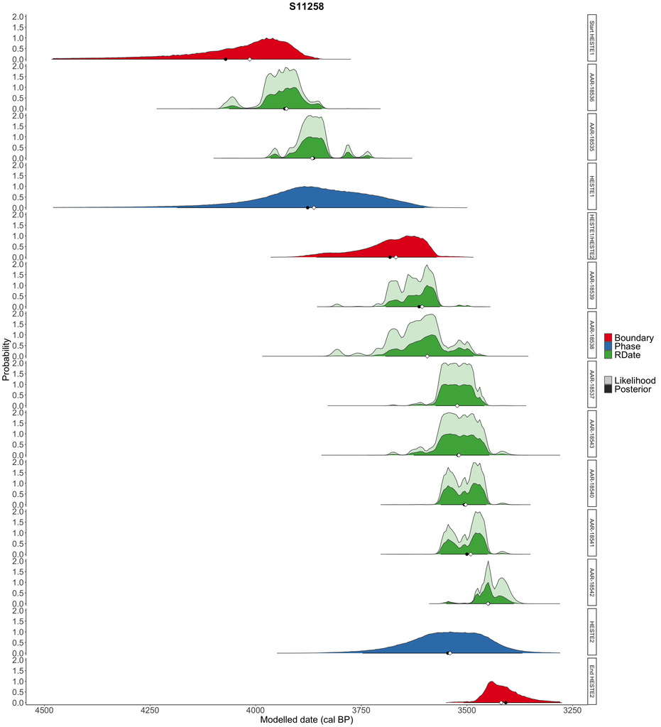

```r
# Change variable names to factors for plotting
calibd$Variable <- factor(calibd$Variable, levels = unique(calibd$Variable), labels = unique(calibd$Variable))
dens$Variable_type <- factor(dens$Variable_type,
                             levels = rev(unique(dens$Variable_type)),
                             labels = c("Boundary", "Phase", "RDate"))

# Keep only modelled date range
calibd <- calibd[which(calibd$Type == "Modelled"),]

# Create a color variable for plotting
colors <- pals::brewer.set1(3)

# Plot
ggplot(dens) +
  # posterior density
  geom_area(aes(x = date, y = prob, fill = Variable_type, alpha = type), color = "grey30") +
  # Add 95.4% range and mean
  geom_pointrange(data = calibd,
                  aes(x = mean, xmin = `To_95.4`, xmax = `From_95.4`, y = 0)) +
  # Add median of 95.4% range
  geom_point(data = calibd,
             aes(x = median, y = 0), shape = 23, size = 3, fill = 'white') +
  # Set color scheme
  scale_fill_manual("", values = colors) +
  # Set degree of transparency
  scale_alpha_manual("", values = c(0.25, 1)) +
  # Plot each sample separately and put into grid
  facet_grid(rows = vars(Variable)) +
  theme_classic() +
  # Set range of x-axis to match the 95.4% range across all dates
  xlim(max(calibd[, "From_95.4"]), min(calibd[, "To_95.4"])) +
  # Set x and y labels
  xlab("Modelled date (cal BP)") +
  ylab("Probability") +
  # Add title
  ggtitle(sid) +
  # Fix size and face of text and position of legend
  theme(plot.title = element_text(hjust = 0.5, face = 'bold', size = 22),
  legend.position = "right",
  legend.direction = "vertical",
  legend.text = element_text(size = 20),
  axis.text = element_text(size = 18),
  axis.title = element_text(size = 20),
  strip.text = element_text(size = 12))
```